# On the Frontier of Water Rights: Beneficial Use and Relinquishment in Settling the Columbia River Basin

## On the Frontier of Water Rights: Beneficial Use and Relinquishment in Settling the Columbia River Basin

##### 2019 UCOWR Annual Conference - Snowbird, Utah

##### [#UCOWR](https://twitter.com/hashtag/AAEADC18)

Nicholas Potter, Jon Yoder

Washington State University

June 12, 2019

## Relinquishment/Forfeiture: modern criticisms

> Any person … who abandons the same, or who voluntarily fails, without sufficient cause, to beneficially use all or any part of said right to divert or withdraw for any period of five successive years … shall relinquish such right or portion thereof
- Water users face potential forfeiture if they do not use their full water, so are incentivized to be inefficient in application.
- Also impedes water transactions, since use is not evaluated except during legal matters or seeking approval for a lease/sale.

## But this begs the (research) question

### What was the economic incentive for beneficial use and relinquishment/forfeiture as a policy, and how does the effect of the policy change as a basin becomes “fully” allocated?

## Economics of the frontier

Based on work by Anderson and Hill (1975) and Anderson and Hill (1990):

- Consider the frontier as a shockwave that passes through an area.
- The shockwave reflects a combination of infrastructure developments that increase the productive capacity of the region.
- In particular, previously unprofitable land may become profitable as infrastructure increases.

## The frontier as a shockwave

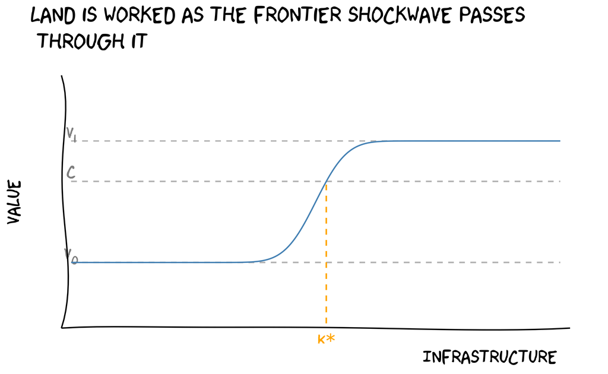

## How do we define property rights?

### Prior Appropriations as a solution

- Allocation on priority of right makes water excludable.
- Allows for collective action (Ostrom and Gardner 1993) among cohesive groups and contracts (Leonard and Libecap 2016) among non-cohesive groups solve the problem of investment in community infrastructure.

## Concerns with Prior Appropriations

- A monopolist could charge water prices that raise \(C\) to \(V1\), extracting all profits from working the land.
- Speculators could claim water, waiting for land prices to rise before selling it.
- A claim holder could abandon their claim and return to it later, extracting fees for water use.

## Beneficial use and forfeiture are necessary

Beneficial use and forfeiture sought to (Zellmer 2007):

- Reduce monopoly and speculation behaviors
- Maximize the use of a scarce resource
- Allow flexibility of use by users

## Timeline of Washington Water Law

- 1873: Water rights and irrigation law in Yakima County
- 1889: Washington becomes a state
- 1890, 1891: Prior appropriation and beneficial use (claim by posting notice)
- 1917: Water Code [RCW 90.03] (claims filed with water master)
- 1967: Relinquishment (RCW 90.14.160)

The filing of a statement of claim pursuant to RCW 90.14.061 which knowingly provides for an overstatement of a right either in quantities of water or times of use claimed shall constitute a misdemeanor punishable by a fine of not more than two hundred fifty dollars or by imprisonment for not more than ninety days, or both.

## Hypothesis

### In early years, less policy and enforcement suggests that earlier claims should have a higher acre-feet to acres ratio.

## Data: Water Rights in Washington

| owner | priority_date | acre_feet | acre_irr | acft_per_acre | source |
| --- | --- | --- | --- | --- | --- |
| POWELL DITCH CO | 1885-03-21 | 62378 | 900 | 69.31 | NACHES RIVER |
| LA FORTUNE DITCH CO | 1892-04-22 | 356400 | 500 | 712.8 | NACHES RIVER |
| Pioneer Water Users Assn | 1896-03-01 | 23000 | 5800 | 3.966 | WENATCHEE RIVER |
| Barkley Irrigating Company | 1900-06-01 | 42448 | 851 | 49.88 | METHOW RIVER |
| SCOTT DITCH CO | 1902-04-20 | 17828 | 500 | 35.66 | NACHES RIVER |

## Washington water claims mapped

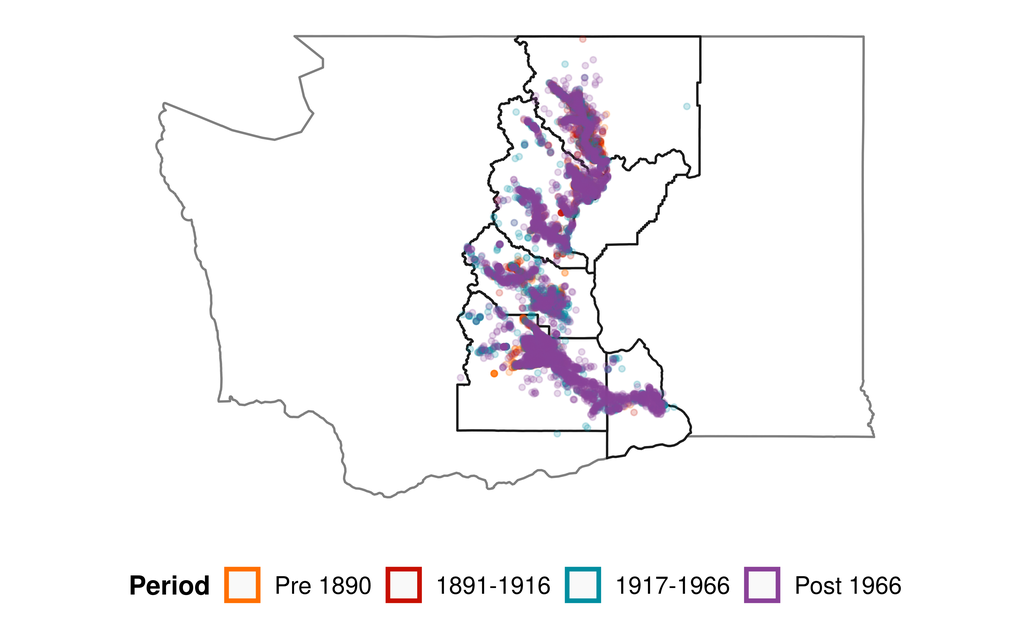

## Washington water claims sizes

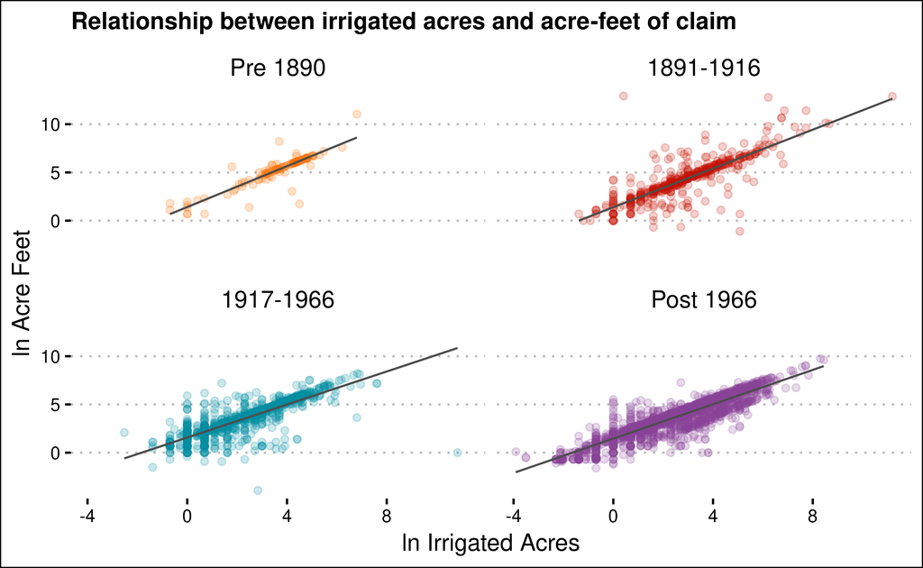

*No real difference between periods.*

## Distribution of acre-feet claims

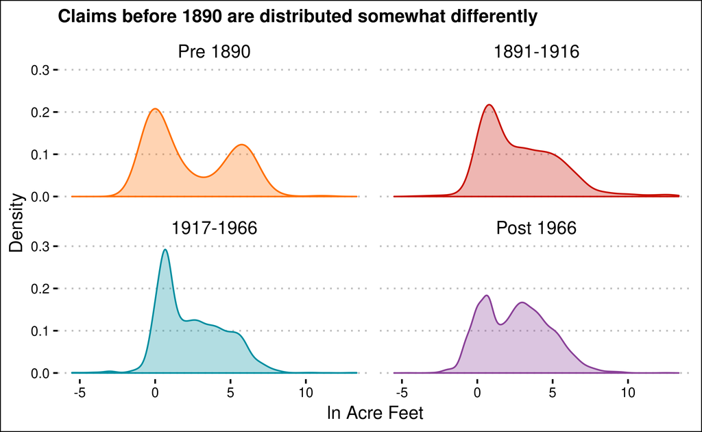

## Distribution of large acre-feet claims

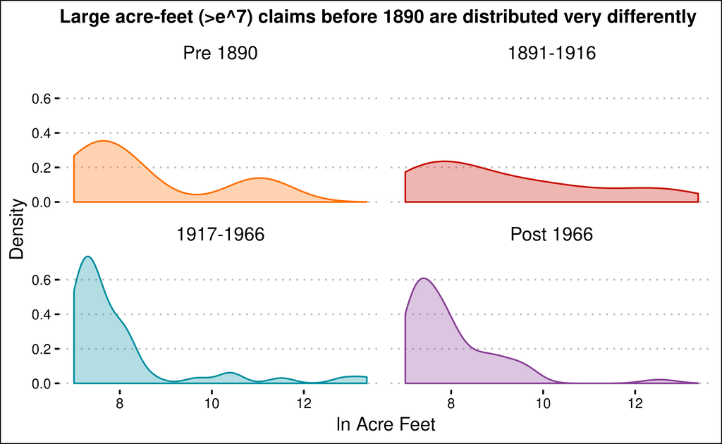

## Next Steps

- Include water rights databases from other states
- Incorporate forfeiture and it’s effects in the present
- Ultimate goal: a formal model of beneficial use and forfeiture during the frontier and now, with data to test implications

## Questions, concerns, comments

Nicholas A Potter

Washington State University

nicholas.a.potter@wsu.edu

twitter: potterzot

github: potterzot

## Selected References

Anderson, Terry L, and Peter J Hill. 1975. “The Evolution of Property Rights: A Study of the American West.” *The Journal of Law and Economics* 18 (1). The University of Chicago Law School:163–79.

———. 1990. “The Race for Property Rights.” *The Journal of Law and Economics* 33 (1). The University of Chicago Press:177–97.

Leonard, Bryan, and Gary Libecap. 2016. “Collective Action by Contract: Prior Appropriation and the Development of Irrigation in the Western United States.” National Bureau of Economic Research. https://doi.org/10.3386/w22185.

Ostrom, Elinor, and Roy Gardner. 1993. “Coping with Asymmetries in the Commons: Self-Governing Irrigation Systems Can Work.” *Journal of Economic Perspectives* 7 (4). American Economic Association:93–112. https://doi.org/10.1257/jep.7.4.93.

Zellmer, Sandra. 2007. “The Anti-Speculation Doctrine and Its Implications for Collaborative Water Management.” *Nevada Law Journal* 8:994.